# Decorrelation-Based Feature Discovery: Seeds

### 1.2.2 Decorrelating using ILAA

ILAA bootstrapped training and testing sets

```r
dataframe_De <- ILAA(dataframe,thr=0.5,verbose=TRUE,bootstrap=30)
```

fast | LM | SV18 SV150 SV8 SV80 SV53 SV38 SV1 SV2 SV3 SV4 SV5 SV6 0.6333333 0.1904762 0.7761905 0.6000000 0.8952381 0.7714286

Included: 210 , Uni p: 0.0007142857 , Base Size: 160 , Rcrit: 0.9432571

1 <R=0.963,thr=0.950>, Top: 27< 1 >Fa= 23,<|><>Tot Used: 49 , Added: 26 , Zero Std: 0 , Max Cor: 0.977

2 <R=0.954,thr=0.950>, Top: 14< 1 >Fa= 29,<|><>Tot Used: 56 , Added: 7 , Zero Std: 0 , Max Cor: 0.961

3 <R=0.951,thr=0.950>, Top: 10< 1 >Fa= 30,<|><>Tot Used: 57 , Added: 1 , Zero Std: 0 , Max Cor: 0.957

4 <R=0.950,thr=0.950>, Top: 9< 1 >Fa= 30,<><>Tot Used: 57 , Added: 0 , Zero Std: 0 , Max Cor: 0.957

7 <R=0.950,thr=0.943>, Top: 17< 1 >Fa= 30,<><>Tot Used: 57 , Added: 0 , Zero Std: 0 , Max Cor: 0.957

[ 7 ], 0.9487696 Decor Dimension: 57 Nused: 57 . Cor to Base: 29 , ABase: 210 , Outcome Base: 0

SV1 SV2 SV7 SV9 SV10 SV11 1 1 1 1 1 1

The heat map of the data

```r
par(op)


  par(cex=0.6,cex.main=0.85,cex.axis=0.7)
  cormat <- cor(dataframe,method="pearson")
  cormat[is.na(cormat)] <- 0
  gplots::heatmap.2(abs(cormat),
                    trace = "none",
  #                  scale = "row",
                    mar = c(5,5),
                    col=rev(heat.colors(5)),
                    main = "Subject Correlation",
                    cexRow = cexheat,
                    cexCol = cexheat,
                     srtCol=45,
                     srtRow=45,
                    key.title=NA,
                    key.xlab="|Pearson Correlation|",
                    xlab="Subject", ylab="Subject")
  diag(cormat) <- 0
  pander::pander(max(abs(cormat)))
```

*0.988*

[figure not shown]

```r
par(op)
```

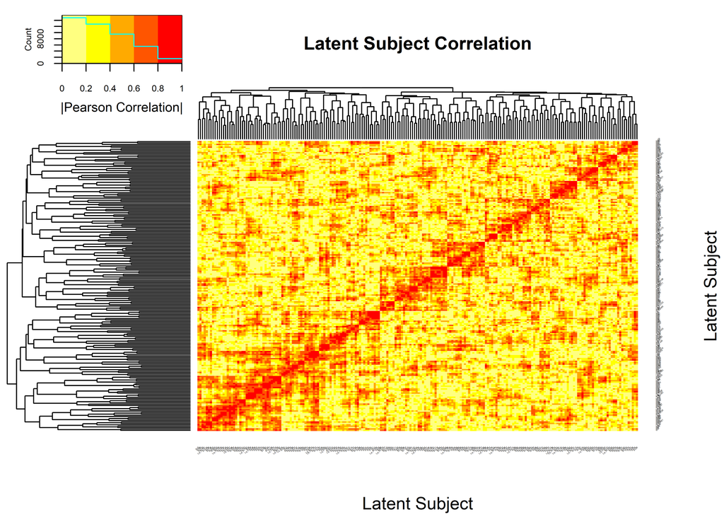

```r
  par(cex=0.6,cex.main=0.85,cex.axis=0.7)
  cormat <- cor(dataframe_De,method="pearson")
  cormat[is.na(cormat)] <- 0
  gplots::heatmap.2(abs(cormat),
                    trace = "none",
  #                  scale = "row",
                    mar = c(5,5),
                    col=rev(heat.colors(5)),
                    main = "Latent Subject Correlation",
                    cexRow = cexheat,
                    cexCol = cexheat,
                     srtCol=45,
                     srtRow=45,
                    key.title=NA,
                    key.xlab="|Pearson Correlation|",
                    xlab="Latent Subject", ylab="Latent Subject")
```

```r
  diag(cormat) <- 0
  pander::pander(max(abs(cormat)))
```

*0.957*

```r
par(op)
```

### 1.2.3 Formulas Network

Displaying the features associations

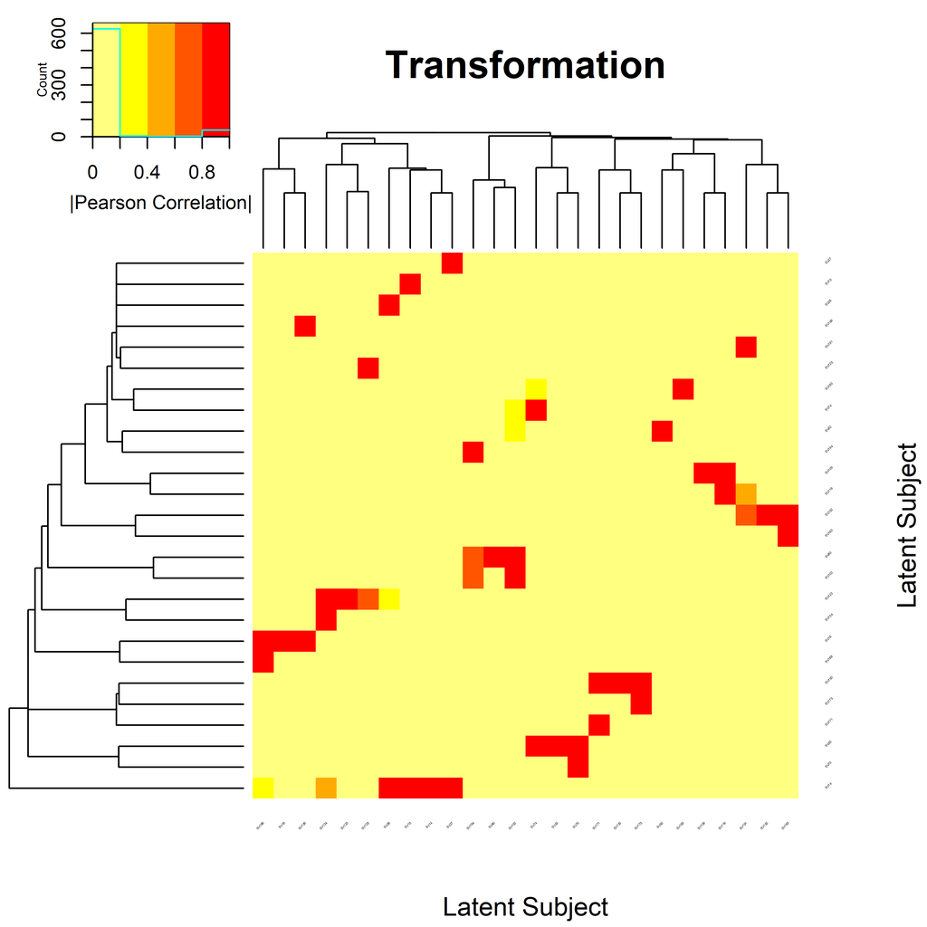

```r
par(op)

  transform <- 1*(attr(dataframe_De,"UPLTM") != 0)
  colnames(transform) <- str_remove_all(colnames(transform),"La_")
  srow <- apply(transform,1,sum) > 2
  rtans <- transform[srow,]
  scol <- apply(rtans,2,sum) > 1*(colnames(rtans) %in% rownames(rtans))
  rtans <- rtans[,scol]
  strans <- unique(c(rownames(rtans),colnames(rtans)))
  transform <- transform[strans,strans]

  transform <- abs(transform*cor(dataframe[,rownames(transform)])) # The weights are proportional to the observed correlation


    gplots::heatmap.2(as.matrix(transform),
                    trace = "none",
  #                  scale = "row",
                    mar = c(5,5),
                    col=rev(heat.colors(5)),
                    main = "Transformation",
                    cexRow = cexheat,
                    cexCol = cexheat,
                     srtCol=45,
                     srtRow=45,
                    key.title=NA,
                    key.xlab="|Pearson Correlation|",
                    xlab="Latent Subject", ylab="Latent Subject")

par(op)
```

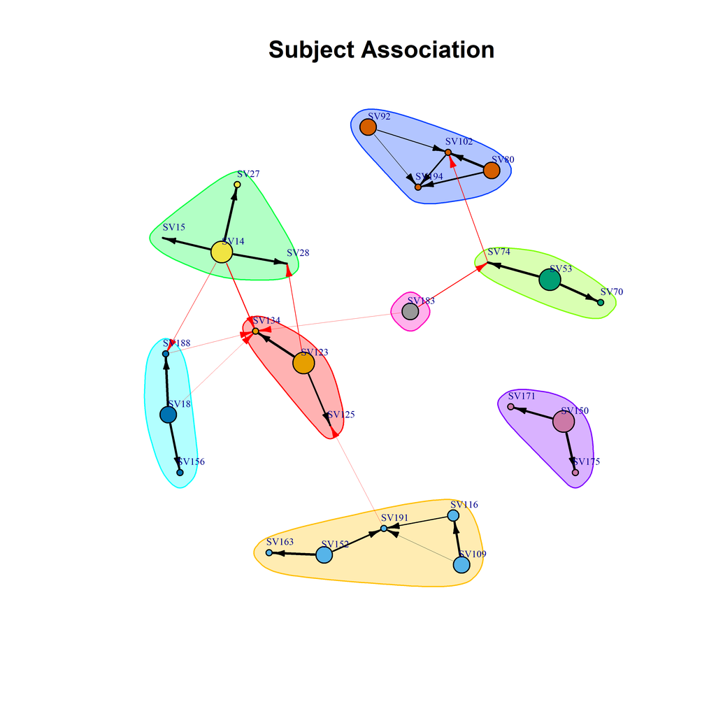

```r
  VertexSize <- attr(dataframe_De,"fscore") # The size depends on the variable independence relevance (fscore)
  names(VertexSize) <- str_remove_all(names(VertexSize),"La_")
  VertexSize <- 0.5 + 9.5*(VertexSize-min(VertexSize))/(max(VertexSize)-min(VertexSize)) # Normalization
  VertexSize <- VertexSize[colnames(transform)]
  gr <- graph_from_adjacency_matrix(transform,mode = "directed",diag = FALSE,weighted=TRUE)
#  gr <- graph_from_adjacency_matrix(transform,mode = "undirected",diag = FALSE,weighted=TRUE)
  gr$layout <- layout_with_fr

#  fc <- cluster_optimal(gr)
#  fc <- cluster_fast_greedy(gr)
#  fc <- cluster_spinglass(gr,spins = 50)
#  fc <- cluster_edge_betweenness(gr)
#  fc <- cluster_leading_eigen(gr)
#  fc <- cluster_louvain(gr)
  fc <- cluster_walktrap (gr,steps=50)
#  fc <- cluster_label_prop(gr)
  plot(fc, gr,
       edge.width = 2*E(gr)$weight,
       vertex.size=VertexSize,
       edge.arrow.size=0.5,
       edge.arrow.width=0.75,
       vertex.label.cex=0.5,
       vertex.label.dist=1,
       main="Subject Association")
```

```r
par(op)

      varratios <- attr(dataframe_De,"VarRatio")
      names(varratios) <- str_remove_all(names(varratios),"La_")
      fscores <- attr(dataframe_De,"fscore")
      names(fscores) <- str_remove_all(names(fscores),"La_")
      clustable <- as.data.frame(cbind(Variable=fc$names,
                                       Cluster=fc$membership,
                                       class=classes[fc$names],
                                       ResidualVariance=round(varratios[fc$names],3),
                                       Fscore=round(fscores[fc$names],3),
                                       VertexSize=round(VertexSize[fc$names],3)
                                       )
                                 )
      rownames(clustable) <- str_replace_all(rownames(clustable),"__","_")
      clustable$Variable <- NULL
      clustable$Cluster <- as.integer(clustable$Cluster)
      clustable$ResidualVariance <- as.numeric(clustable$ResidualVariance)
      clustable$Fscore <- as.numeric(clustable$Fscore)
      clustable <- clustable[order(-clustable$ResidualVariance),]
      clustable <- clustable[order(clustable$Cluster),]

pander::pander(as.matrix(clustable))
```

|  | Cluster | class | ResidualVariance | Fscore | VertexSize |
| --- | --- | --- | --- | --- | --- |
| **SV123** | 1 | 2 | 1.000 | 1.995 | 9.993 |
| **SV134** | 1 | 2 | 0.045 | -1.001 | 2.872 |
| **SV125** | 1 | 2 | 0.002 | -1.997 | 0.504 |
| **SV109** | 2 | 2 | 1.000 | 1.000 | 7.628 |
| **SV152** | 2 | 3 | 1.000 | 1.000 | 7.628 |
| **SV116** | 2 | 2 | 0.080 | 0.000 | 5.251 |
| **SV191** | 2 | 3 | 0.079 | -1.000 | 2.874 |
| **SV163** | 2 | 3 | 0.067 | -1.000 | 2.874 |
| **SV53** | 3 | 1 | 1.000 | 1.996 | 9.996 |
| **SV70** | 3 | 1 | 0.044 | -1.000 | 2.874 |
| **SV74** | 3 | 2 | 0.006 | -1.999 | 0.5 |
| **SV14** | 4 | 1 | 1.000 | 1.998 | 10 |
| **SV27** | 4 | 1 | 0.055 | -1.000 | 2.874 |
| **SV15** | 4 | 1 | 0.007 | -1.999 | 0.501 |
| **SV28** | 4 | 1 | 0.006 | -1.998 | 0.502 |
| **SV18** | 5 | 1 | 1.000 | 1.001 | 7.631 |
| **SV156** | 5 | 3 | 0.061 | -1.000 | 2.874 |
| **SV188** | 5 | 3 | 0.023 | -1.000 | 2.874 |
| **SV80** | 6 | 2 | 1.000 | 1.000 | 7.628 |
| **SV92** | 6 | 2 | 1.000 | 1.000 | 7.628 |
| **SV194** | 6 | 3 | 0.077 | -1.000 | 2.874 |
| **SV102** | 6 | 2 | 0.003 | -1.001 | 2.871 |
| **SV150** | 7 | 3 | 1.000 | 1.997 | 9.997 |
| **SV171** | 7 | 3 | 0.081 | -1.000 | 2.874 |
| **SV175** | 7 | 3 | 0.039 | -1.000 | 2.874 |
| **SV183** | 8 | 3 | 1.000 | 1.000 | 7.628 |

```r
pander::pander(table(clustable$Cluster,clustable$class))
```

| 1 | 2 | 3 |
| --- | --- | --- |
| 0 | 3 | 0 |
| 0 | 2 | 3 |
| 2 | 1 | 0 |
| 4 | 0 | 0 |
| 1 | 0 | 2 |
| 0 | 3 | 1 |
| 0 | 0 | 3 |
| 0 | 0 | 1 |